# Summarization strategy comparison for Data-driven analysis of isobarically labeled proteomic data.

Joris Van Houtven, Piotr Prostko

January 13, 2021,22:09

This notebook is one in a series of many, where we explore how different data analysis strategies affect the outcome of a proteomics experiment based on isobaric labeling and mass spectrometry. Each analysis strategy or ‘workflow’ can be divided up into different components; it is recommend you read more about that in the introduction notebook. In this notebook specifically, we investigate the effect of varying the **Summarization** component on the outcome of the differential expression results. The three component variants are: **median summarization**, **iPQF**, **sum summarization**.

The R packages and helper scripts necessary to run this notebook are listed below and each code section can be expanded in a similar fashion. You can also download the entire notebook source code.

```r
library(ggplot2)
library(stringi)
library(gridExtra)
library(dendextend)
library(kableExtra)
library(limma)
library(psych)
library(MSnbase)  # CAREFUL! load this BEFORE tidyverse, or you will screw up the rename function.
library(tidyverse)
library(CONSTANd)  # install from source: https://github.com/PDiracDelta/CONSTANd/
source('other_functions.R')
source('plotting_functions.R')
```

Let’s load the PSM data set

```r
data.list <- readRDS('input_data.rds')
dat.l <- data.list$dat.l # data in long format
dat.l
```

```
## # A tibble: 464,224 x 19
##    Mixture TechRepMixture Condition BioReplicate Run   Channel Protein Peptide    RT Charge
##    <fct>   <fct>          <fct>     <fct>        <fct> <fct>   <fct>   <fct>   <dbl> <fct>
##  1 Mixtur~ 1              1         Mixture2_1   Mixt~ 127C    P21291  [K].gF~  145. 2
##  2 Mixtur~ 1              0.5       Mixture2_0.5 Mixt~ 127N    P21291  [K].gF~  145. 2
##  3 Mixtur~ 1              0.125     Mixture2_0.~ Mixt~ 128C    P21291  [K].gF~  145. 2
##  4 Mixtur~ 1              0.667     Mixture2_0.~ Mixt~ 128N    P21291  [K].gF~  145. 2
##  5 Mixtur~ 1              0.667     Mixture2_0.~ Mixt~ 129C    P21291  [K].gF~  145. 2
##  6 Mixtur~ 1              1         Mixture2_1   Mixt~ 129N    P21291  [K].gF~  145. 2
##  7 Mixtur~ 1              0.5       Mixture2_0.5 Mixt~ 130C    P21291  [K].gF~  145. 2
##  8 Mixtur~ 1              0.125     Mixture2_0.~ Mixt~ 130N    P21291  [K].gF~  145. 2
##  9 Mixtur~ 1              1         Mixture2_1   Mixt~ 127C    P30511  [K].wA~  137. 2
## 10 Mixtur~ 1              0.5       Mixture2_0.5 Mixt~ 127N    P30511  [K].wA~  137. 2
## # ... with 464,214 more rows, and 9 more variables: PTM <fct>, intensity <dbl>,
## #   TotalIntensity <dbl>, Ions.Score <int>, DeltaMZ <dbl>, isoInterOk <lgl>, noNAs <lgl>,
## #   onehit.protein <lgl>, shared.peptide <lgl>
```

After this thresholding there are 19 UPS1 proteins remaining, even though 48 were originally spiked in.

```r
# which proteins were spiked in?
spiked.proteins <- dat.l %>% distinct(Protein) %>% filter(stri_detect(Protein, fixed='ups')) %>% pull %>% as.character
remove_factors(spiked.proteins)
```

```
##  [1] "P02787ups"   "P02788ups"   "P01133ups"   "P69905ups"   "P01008ups"   "P02741ups"
##  [7] "P01375ups"   "P10636-8ups" "O00762ups"   "P62988ups"   "P10145ups"   "P05413ups"
## [13] "P00915ups"   "P02753ups"   "P02144ups"   "P01344ups"   "P01579ups"   "P00709ups"
## [19] "P01127ups"
```

```r
#TEMP -remove!
# tmp=dat.l %>% distinct(Protein) %>% pull %>% as.character
# dat.l <- dat.l %>% filter(Protein %in% c(tmp[sample(1:length(tmp), size=200)], spiked.proteins))
# unique(dat.l$Protein)
```

We pick technical replicates with a dilution of 0.5 as the reference condition of interest. Each condition is represented by two of eight reporter Channels in each Run.

```r
sample.info
```

```
## # A tibble: 32 x 7
##    Run        Run.short Channel Sample          Sample.short Condition Color
##    <fct>      <fct>     <fct>   <fct>           <fct>        <chr>     <chr>
##  1 Mixture1_1 Mix1_1    127C    Mixture1_1:127C Mix1_1:127C  0.125     black
##  2 Mixture1_1 Mix1_1    127N    Mixture1_1:127N Mix1_1:127N  0.667     green
##  3 Mixture1_1 Mix1_1    128C    Mixture1_1:128C Mix1_1:128C  1         red
##  4 Mixture1_1 Mix1_1    128N    Mixture1_1:128N Mix1_1:128N  0.5       blue
##  5 Mixture1_1 Mix1_1    129C    Mixture1_1:129C Mix1_1:129C  0.5       blue
##  6 Mixture1_1 Mix1_1    129N    Mixture1_1:129N Mix1_1:129N  0.125     black
##  7 Mixture1_1 Mix1_1    130C    Mixture1_1:130C Mix1_1:130C  0.667     green
##  8 Mixture1_1 Mix1_1    130N    Mixture1_1:130N Mix1_1:130N  1         red
##  9 Mixture1_2 Mix1_2    127C    Mixture1_2:127C Mix1_2:127C  0.125     black
## 10 Mixture1_2 Mix1_2    127N    Mixture1_2:127N Mix1_2:127N  0.667     green
## # ... with 22 more rows
```

```r
referenceCondition
```

```
## [1] "0.5"
```

```r
channelNames
```

```
## [1] "127C" "127N" "128C" "128N" "129C" "129N" "130C" "130N"
```

# 1 Unit scale component: log2 transformation of reporter ion intensities

We use the default unit scale: the log2-transformed reportion ion intensities.

```r
dat.unit.l <- dat.l %>% mutate(response=log2(intensity)) %>% select(-intensity)
dat.unit.l
```

```
## # A tibble: 464,224 x 19
##    Mixture TechRepMixture Condition BioReplicate Run   Channel Protein Peptide    RT Charge
##    <fct>   <fct>          <fct>     <fct>        <fct> <fct>   <fct>   <fct>   <dbl> <fct>
##  1 Mixtur~ 1              1         Mixture2_1   Mixt~ 127C    P21291  [K].gF~  145. 2
##  2 Mixtur~ 1              0.5       Mixture2_0.5 Mixt~ 127N    P21291  [K].gF~  145. 2
##  3 Mixtur~ 1              0.125     Mixture2_0.~ Mixt~ 128C    P21291  [K].gF~  145. 2
##  4 Mixtur~ 1              0.667     Mixture2_0.~ Mixt~ 128N    P21291  [K].gF~  145. 2
##  5 Mixtur~ 1              0.667     Mixture2_0.~ Mixt~ 129C    P21291  [K].gF~  145. 2
##  6 Mixtur~ 1              1         Mixture2_1   Mixt~ 129N    P21291  [K].gF~  145. 2
##  7 Mixtur~ 1              0.5       Mixture2_0.5 Mixt~ 130C    P21291  [K].gF~  145. 2
##  8 Mixtur~ 1              0.125     Mixture2_0.~ Mixt~ 130N    P21291  [K].gF~  145. 2
##  9 Mixtur~ 1              1         Mixture2_1   Mixt~ 127C    P30511  [K].wA~  137. 2
## 10 Mixtur~ 1              0.5       Mixture2_0.5 Mixt~ 127N    P30511  [K].wA~  137. 2
## # ... with 464,214 more rows, and 9 more variables: PTM <fct>, TotalIntensity <dbl>,
## #   Ions.Score <int>, DeltaMZ <dbl>, isoInterOk <lgl>, noNAs <lgl>, onehit.protein <lgl>,
## #   shared.peptide <lgl>, response <dbl>
```

# 2 Normalization component: medianSweeping (1)

Since medianSweeping needs to be applied on matrix-like data, let’s switch to wide format. (Actually, this is semi-wide, since the Channel columns still have contributions form all Runs, but that’s OK because in the next step we split by Run.)

```r
# switch to wide format
dat.unit.w <- pivot_wider(data = dat.unit.l, id_cols=-one_of(c('Condition', 'BioReplicate')), names_from=Channel, values_from=response)
dat.unit.w
```

```
## # A tibble: 58,028 x 23
##    Mixture TechRepMixture Run   Protein Peptide    RT Charge PTM   TotalIntensity Ions.Score
##    <fct>   <fct>          <fct> <fct>   <fct>   <dbl> <fct>  <fct>          <dbl>      <int>
##  1 Mixtur~ 1              Mixt~ P21291  [K].gF~ 145.  2      N-Te~        398539.         65
##  2 Mixtur~ 1              Mixt~ P30511  [K].wA~ 137.  2      N-Te~        183205.         27
##  3 Mixtur~ 1              Mixt~ P02787~ [K].sA~ 149.  3      N-Te~        505761.         35
##  4 Mixtur~ 1              Mixt~ Q9UBQ5  [K].iD~ 202.  2      N-Te~        121401.         72
##  5 Mixtur~ 1              Mixt~ Q5H9R7  [R].tG~ 107.  2      N-Te~         99914.         23
##  6 Mixtur~ 1              Mixt~ P43490  [K].nA~  99.8 3      N-Te~        500038.         15
##  7 Mixtur~ 1              Mixt~ P43897  [R].fE~ 113.  2      N-Te~        102360.         66
##  8 Mixtur~ 1              Mixt~ Q6XQN6  [R].lQ~ 190.  3      N-Te~        106366.         10
##  9 Mixtur~ 1              Mixt~ P49327  [R].dL~ 215.  3      N-Te~         19204.         53
## 10 Mixtur~ 1              Mixt~ Q02790  [K].sN~  58.8 2      N-Te~         29855.         67
## # ... with 58,018 more rows, and 13 more variables: DeltaMZ <dbl>, isoInterOk <lgl>,
## #   noNAs <lgl>, onehit.protein <lgl>, shared.peptide <lgl>, `127C` <dbl>, `127N` <dbl>,
## #   `128C` <dbl>, `128N` <dbl>, `129C` <dbl>, `129N` <dbl>, `130C` <dbl>, `130N` <dbl>
```

Now let’s sweep the medians of all the rows. No need to split this per Run, because each row contains only values from one Run and each median calculation is independent of the other rows. We will sweep the columns on the protein level – as suggested by HERBRICH ET AL – after summarization.

```r
# subtract the spectrum median log2intensity from the observed log2intensities
dat.norm.w <- dat.unit.w
dat.norm.w[,channelNames] <- median_sweep(dat.norm.w[,channelNames], 1, '-')
dat.norm.w
```

```
## # A tibble: 58,028 x 23
##    Mixture TechRepMixture Run   Protein Peptide    RT Charge PTM   TotalIntensity Ions.Score
##    <fct>   <fct>          <fct> <fct>   <fct>   <dbl> <fct>  <fct>          <dbl>      <int>
##  1 Mixtur~ 1              Mixt~ P21291  [K].gF~ 145.  2      N-Te~        398539.         65
##  2 Mixtur~ 1              Mixt~ P30511  [K].wA~ 137.  2      N-Te~        183205.         27
##  3 Mixtur~ 1              Mixt~ P02787~ [K].sA~ 149.  3      N-Te~        505761.         35
##  4 Mixtur~ 1              Mixt~ Q9UBQ5  [K].iD~ 202.  2      N-Te~        121401.         72
##  5 Mixtur~ 1              Mixt~ Q5H9R7  [R].tG~ 107.  2      N-Te~         99914.         23
##  6 Mixtur~ 1              Mixt~ P43490  [K].nA~  99.8 3      N-Te~        500038.         15
##  7 Mixtur~ 1              Mixt~ P43897  [R].fE~ 113.  2      N-Te~        102360.         66
##  8 Mixtur~ 1              Mixt~ Q6XQN6  [R].lQ~ 190.  3      N-Te~        106366.         10
##  9 Mixtur~ 1              Mixt~ P49327  [R].dL~ 215.  3      N-Te~         19204.         53
## 10 Mixtur~ 1              Mixt~ Q02790  [K].sN~  58.8 2      N-Te~         29855.         67
## # ... with 58,018 more rows, and 13 more variables: DeltaMZ <dbl>, isoInterOk <lgl>,
## #   noNAs <lgl>, onehit.protein <lgl>, shared.peptide <lgl>, `127C` <dbl>, `127N` <dbl>,
## #   `128C` <dbl>, `128N` <dbl>, `129C` <dbl>, `129N` <dbl>, `130C` <dbl>, `130N` <dbl>
```

These normalized quantification values are now perfectly comparable!

# 3 Summarization component

Now, let’s look at three ways to summarize quantification values from PSM to peptide (first step) to protein (second step).

```r
dat.norm.summ.w <- emptyList(variant.names)
dat.nonnorm.summ.w <- emptyList(variant.names)
```

## 3.1 Median summarization

```r
median_summarization <- function(dat) {
  # group by (run,)protein,peptide then summarize twice (once on each level)
  # add select() statement because summarise_at is going bananas over character columns
  return(dat %>% group_by(Run, Protein, Peptide) %>% select(Run, Protein, Peptide, channelNames) %>% summarise_at(.vars = channelNames, .funs = median) %>% select(Run, Protein, channelNames) %>% summarise_at(.vars = channelNames, .funs = median) %>% ungroup())
}

# normalized data
dat.norm.summ.w$median <- median_summarization(dat.norm.w)
dat.norm.summ.w$median[, channelNames]
```

```
## # A tibble: 12,175 x 8
##      `127C`  `127N`  `128C`  `128N`  `129C`  `129N`   `130C`   `130N`
##       <dbl>   <dbl>   <dbl>   <dbl>   <dbl>   <dbl>    <dbl>    <dbl>
##  1 -0.0215  -0.0329 -0.0453  0.0905  0.0584 -0.0304 -0.0361   0.00761
##  2 -0.130    0.0686  0.0648  0.0162 -0.0296  0.117   0.00160 -0.110
##  3 -0.0429  -0.0919  0.113   0.0857  0.127  -0.0404 -0.0208   0.0301
##  4  0.0111  -0.140  -0.335   0.0130  0.0869  0.0785 -0.215   -0.0111
##  5  0.563    0.0247  0.537  -0.0330 -0.471  -0.0247  0.0887  -0.410
##  6  0.169   -0.193  -0.0838  0.107  -0.0315 -0.0284  0.0505   0.0284
##  7 -0.0737  -0.0608  0.112  -0.0322  0.0254  0.0731 -0.0159   0.0412
##  8 -0.0733  -0.240  -0.0949 -0.138  -0.290   0.0453  0.274    0.122
##  9 -0.00860 -0.159  -0.0218 -0.203   0.0479  0.0468  0.108    0.0825
## 10 -0.120   -0.0881  0.0928  0.0701  0.0122 -0.0518 -0.0122   0.0213
## # ... with 12,165 more rows
```

```r
head(rowSums(dat.norm.summ.w$median[, channelNames]))
```

```
## [1] -0.009778765 -0.001125604  0.159767959 -0.511234622  0.275193474  0.018406886
```

Notice that the row sums are not equal to Ncols anymore, because the median summarization does not preserve them (but mean summarization does).

Let’s also summarize the non-normalized data for comparison later on .

```r
# non-normalized data
dat.nonnorm.summ.w$median <- median_summarization(dat.unit.w)
```

## 3.2 iPQF

```r
iPQF_summarization <- function(x) {
  dat <- split(x, x$Run)  # apply iPQF to each Run separately
  # first make an MSnSet object
  exprs <- lapply(dat, function(y) as.matrix(y[,channelNames]))
  fdata <- lapply(dat, function(y) as.data.frame(y %>% select(-channelNames)) %>% rename(sequence='Peptide', accession='Protein', charge='Charge', modifications='PTM', mass_to_charge='DeltaMZ', search_engine_score='Ions.Score', Intensity='TotalIntensity'))
  mss <- emptyList(names(dat))
  for (i in seq_along(mss)) { mss[[i]] <- MSnSet(exprs = exprs[[i]], fData = fdata[[i]]) }
  # then summarize
  mss.norm <- lapply(mss, function(y) combineFeatures(y, method='iPQF', groupBy = fData(y)$accession, ratio.calc='none'))
  mss.norm.tibble <- lapply(mss.norm, function(y) tibble(cbind(data.frame(Run=fData(y)$Run), rownames_to_column(as.data.frame(exprs(y)), var='Protein'))))
  return(bind_rows(mss.norm.tibble))
}
# normalized data
dat.norm.summ.w$iPQF <- iPQF_summarization(dat.norm.w)
```

```r
# non-normalized data
dat.nonnorm.summ.w$iPQF <- iPQF_summarization(dat.unit.w)
```

## 3.3 Sum summarization

Sum summarization is completely analogous to the median summarization, except that we sum values instead of taking the median. Note that sum normalization is NOT equivalent to mean normalization: yes, rows containing NA values are removed, but there may be multiple PSMs per peptide and multiple peptides per protein. Since we know that there is a strong peptide-run interaction, summing values across peptides per protein may result in strong bias by run.

```r
sum_summarization <- function(dat) {
  # group by (run,)protein,peptide then summarize twice (once on each level)
  # add select() statement because summarise_at is going bananas over character columns
  return(dat %>% group_by(Run, Protein, Peptide) %>% select(Run, Protein, Peptide, channelNames) %>% summarise_at(.vars = channelNames, .funs = median) %>% select(Run, Protein, channelNames) %>% summarise_at(.vars = channelNames, .funs = sum) %>% ungroup())
}
# normalized data
dat.norm.summ.w$sum <- sum_summarization(dat.norm.w)
```

```r
# non-normalized data
dat.nonnorm.summ.w$sum <- sum_summarization(dat.unit.w)
```

# 4 Normalization component: medianSweeping (2)

Now that the data is on the protein level, let’s sweep all values separately per protein in the columns/samples. This is *slightly* different from sweeping before the summarization step because the median of medians is not the same as the grand median, but this does not introduce bias.

```r
# medianSweeping: in each channel, subtract median computed across all proteins within the channel
# do the above separately for each MS run
dat.norm.summ.w <- lapply(dat.norm.summ.w, function(x) {
  x.split <- split(x, x$Run)
  x.split.norm  <- lapply(x.split, function(y) {
    y[,channelNames] <- median_sweep(y[,channelNames], 2, '-')
    return(y)})
  dat.norm.summ.w <- bind_rows(x.split.norm)
})
```

# 5 QC plots

Before getting to the DEA section, let’s do some basic quality control and take a sneak peek at the differences between the component varints we’ve chosen. First, however, we should make the data completely wide, so that each sample gets it’s own unique column.

```r
# make data completely wide (also across runs)
## normalized data
dat.norm.summ.w2 <- lapply(dat.norm.summ.w, function(x) {
  return(x %>% pivot_wider(names_from = Run, values_from = all_of(channelNames), names_glue = "{Run}:{.value}"))
})
colnames(dat.norm.summ.w2$median)
```

```
##  [1] "Protein"         "Mixture1_1:127C" "Mixture1_2:127C" "Mixture2_1:127C" "Mixture2_2:127C"
##  [6] "Mixture1_1:127N" "Mixture1_2:127N" "Mixture2_1:127N" "Mixture2_2:127N" "Mixture1_1:128C"
## [11] "Mixture1_2:128C" "Mixture2_1:128C" "Mixture2_2:128C" "Mixture1_1:128N" "Mixture1_2:128N"
## [16] "Mixture2_1:128N" "Mixture2_2:128N" "Mixture1_1:129C" "Mixture1_2:129C" "Mixture2_1:129C"
## [21] "Mixture2_2:129C" "Mixture1_1:129N" "Mixture1_2:129N" "Mixture2_1:129N" "Mixture2_2:129N"
## [26] "Mixture1_1:130C" "Mixture1_2:130C" "Mixture2_1:130C" "Mixture2_2:130C" "Mixture1_1:130N"
## [31] "Mixture1_2:130N" "Mixture2_1:130N" "Mixture2_2:130N"
```

```r
## non-normalized data
dat.nonnorm.summ.w2 <- lapply(dat.nonnorm.summ.w, function(x){
  return(x %>% pivot_wider(names_from = Run, values_from = all_of(channelNames), names_glue = "{Run}:{.value}") )
})
```

## 5.1 Boxplots

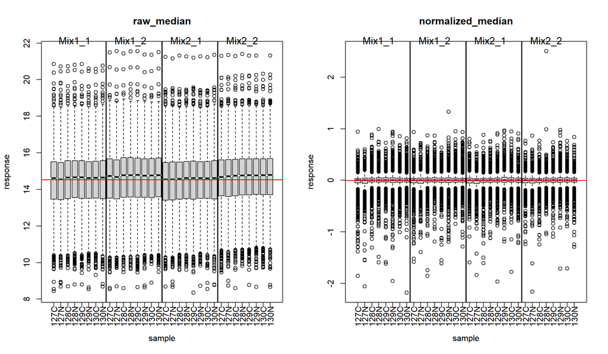

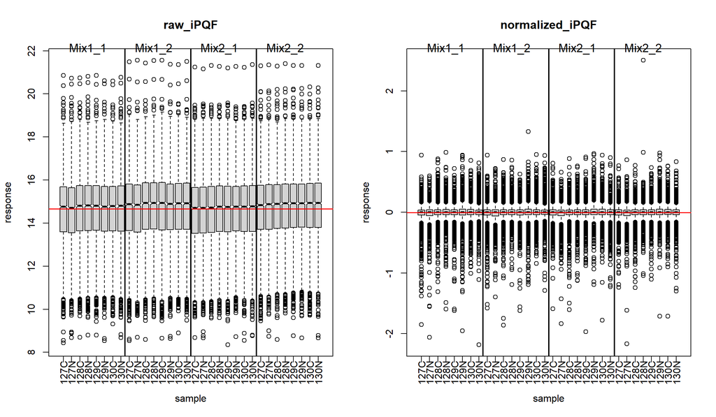

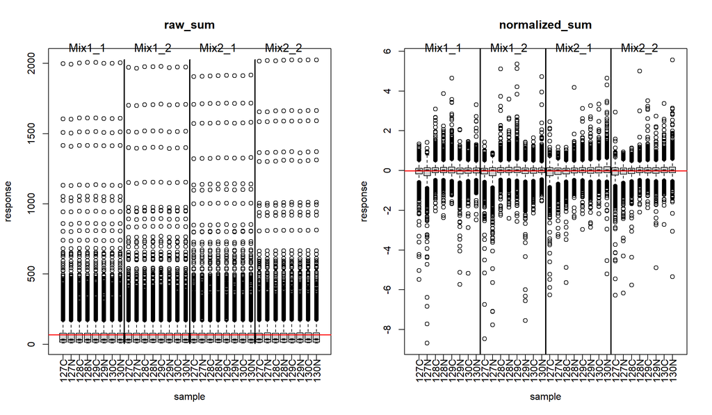

```r
# use (half-)wide format
par(mfrow=c(1,2))
for (i in 1:n.comp.variants){
  boxplot_w(dat.nonnorm.summ.w[[variant.names[i]]],sample.info, paste('raw', variant.names[i], sep='_'))
  boxplot_w(dat.norm.summ.w[[variant.names[i]]], sample.info, paste('normalized', variant.names[i], sep='_'))}
```

## 5.2 MA plots

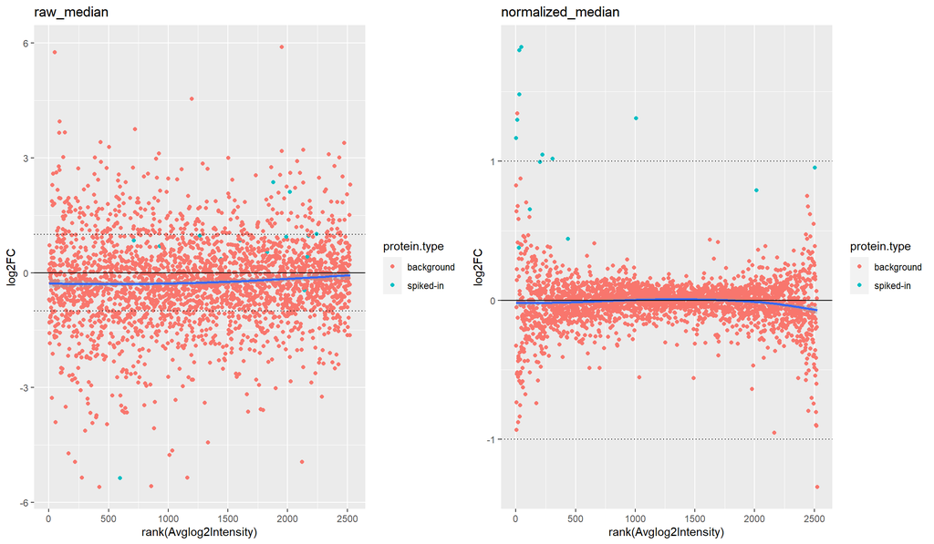

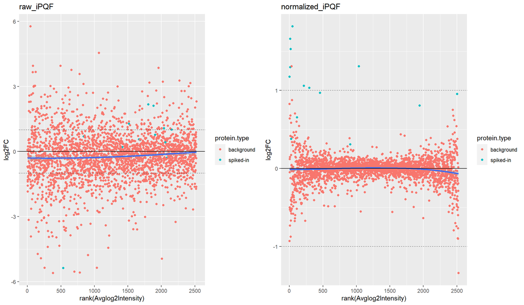

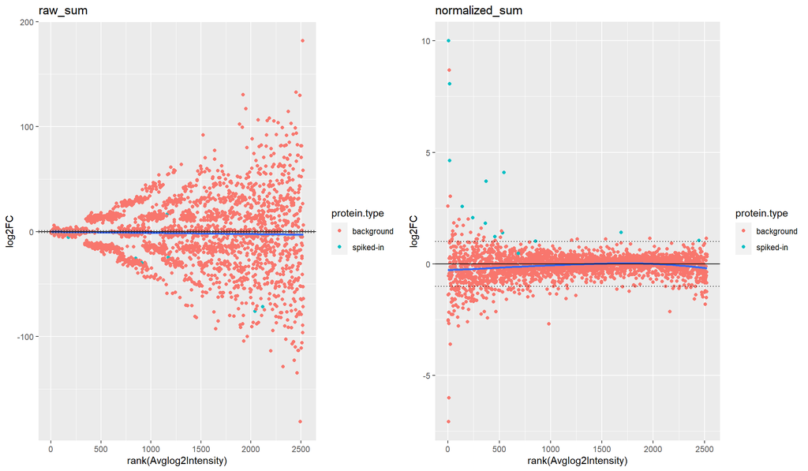

```r
for (i in 1:n.comp.variants){
  p1 <- maplot_ils(dat.nonnorm.summ.w2[[variant.names[i]]], 'Mixture2_1:127C', 'Mixture1_2:129N', scale.vec, paste('raw', variant.names[i], sep='_'), spiked.proteins)
  p2 <- maplot_ils(dat.norm.summ.w2[[variant.names[i]]], 'Mixture2_1:127C', 'Mixture1_2:129N', scale.vec, paste('normalized', variant.names[i], sep='_'), spiked.proteins)
grid.arrange(p1, p2, ncol=2)}
```

To increase the robustness of these results, let’s make some more MA plots, but now for all samples from condition `1` and condition `0.125` (quantification values averaged within condition). Indeed, even the raw, unnormalized data now show less variability, and again even more so for the normalized data. In this case, even the Sum summarized data experienced variance reduction, although not as much.

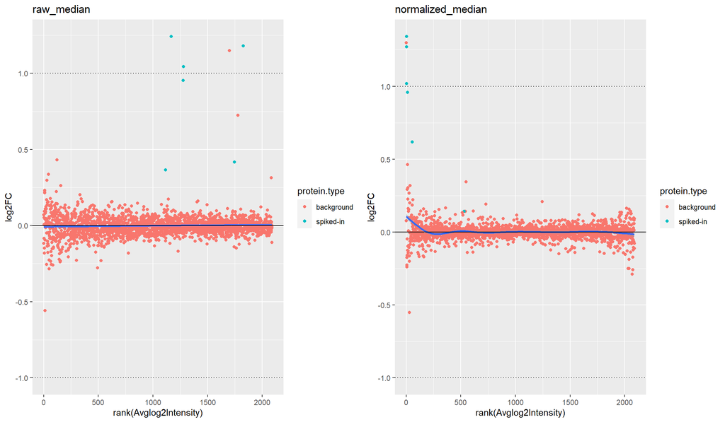

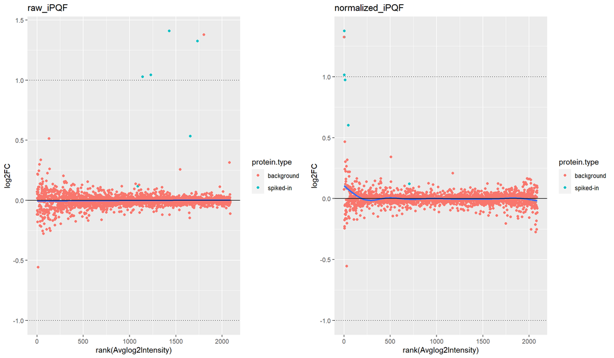

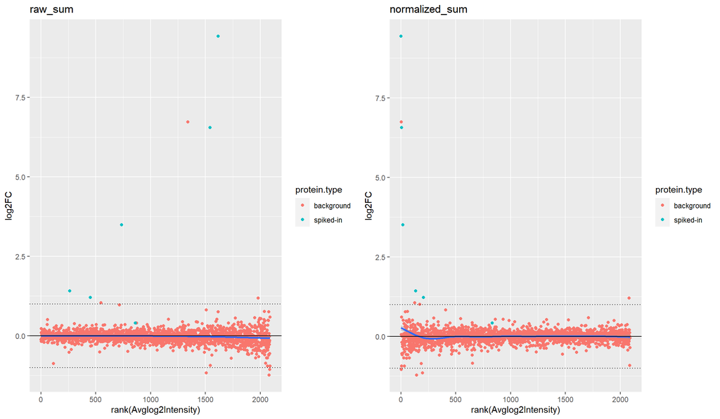

```r
channels.num <- sample.info %>% filter(Condition=='1') %>% select(Sample) %>% pull
channels.denom <- sample.info %>% filter(Condition=='0.125') %>% select(Sample) %>% pull
for (i in 1: n.comp.variants){
  p1 <- maplot_ils(dat.nonnorm.summ.w2[[variant.names[i]]], channels.num, channels.denom, scale=scale.vec, paste('raw', variant.names[i], sep='_'), spiked.proteins)
  p2 <- maplot_ils(dat.norm.summ.w2[[variant.names[i]]], channels.num, channels.denom, scale=scale.vec, paste('normalized', variant.names[i], sep='_'), spiked.proteins)
grid.arrange(p1, p2, ncol=2)}
```

## 5.3 PCA plots

### 5.3.1 Using all proteins

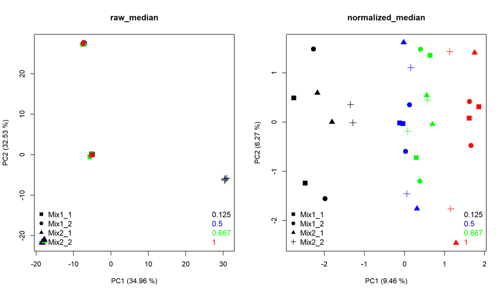

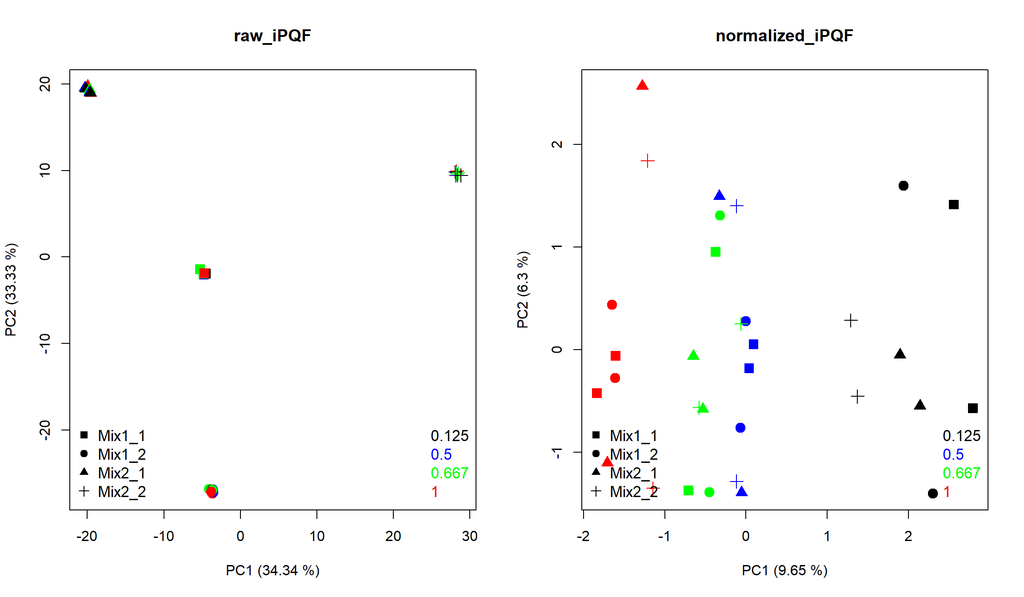

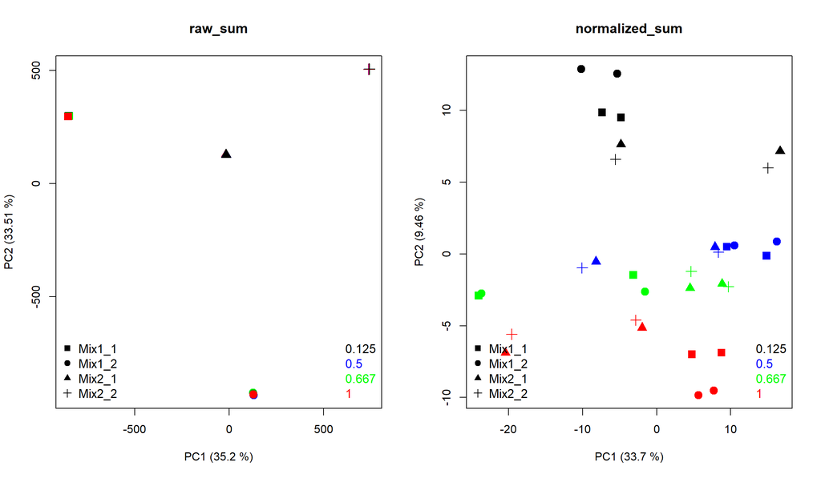

```r
par(mfrow=c(1,2))
for (i in 1:n.comp.variants){
  pcaplot_ils(dat.nonnorm.summ.w2[[variant.names[i]]] %>% select(-'Protein'), info=sample.info, paste('raw', variant.names[i], sep='_'))
  pcaplot_ils(dat.norm.summ.w2[[variant.names[i]]] %>% select(-'Protein'), info=sample.info, paste('normalized', variant.names[i], sep='_'))}
```

There are only 19 proteins supposed to be differentially expressed in this data set, which is only a very small proportion.

### 5.3.2 Using spiked proteins only

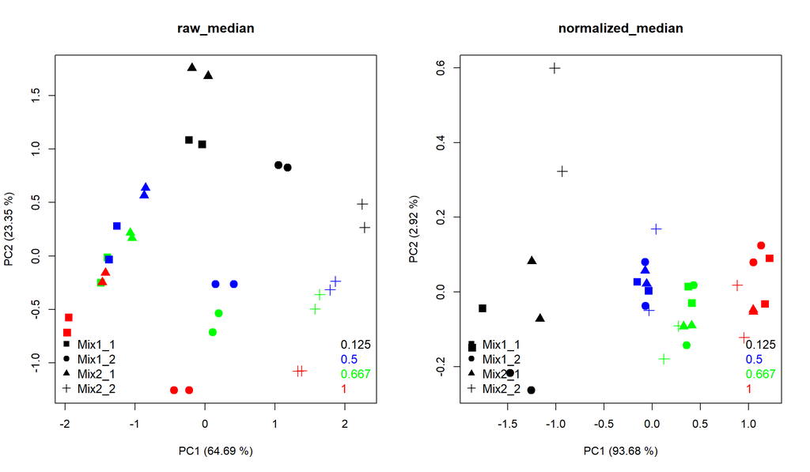

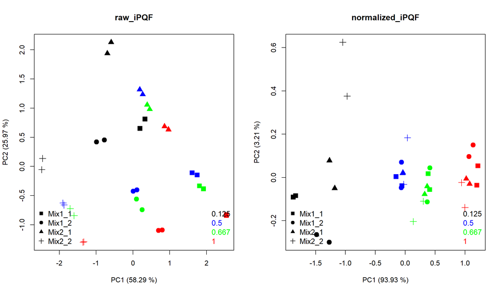

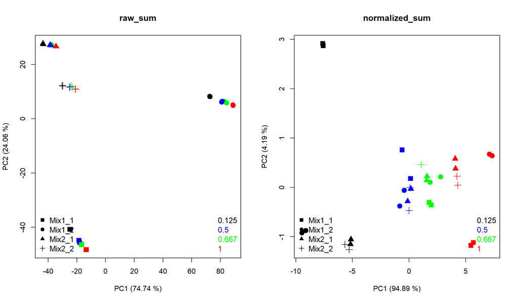

```r
par(mfrow=c(1,2))
for (i in 1:n.comp.variants){
  pcaplot_ils(dat.nonnorm.summ.w2[[variant.names[i]]] %>% filter(Protein %in% spiked.proteins) %>% select(-'Protein'), info=sample.info, paste('raw', variant.names[i], sep='_'))
  pcaplot_ils(dat.norm.summ.w2[[variant.names[i]]] %>% filter(Protein %in% spiked.proteins) %>% select(-'Protein'), info=sample.info, paste('normalized', variant.names[i], sep='_'))}
```

Note that in a real situation without spiked proteins, you might plot data corresponding to the top X most differential proteins instead.

## 5.4 HC (hierarchical clustering) plots

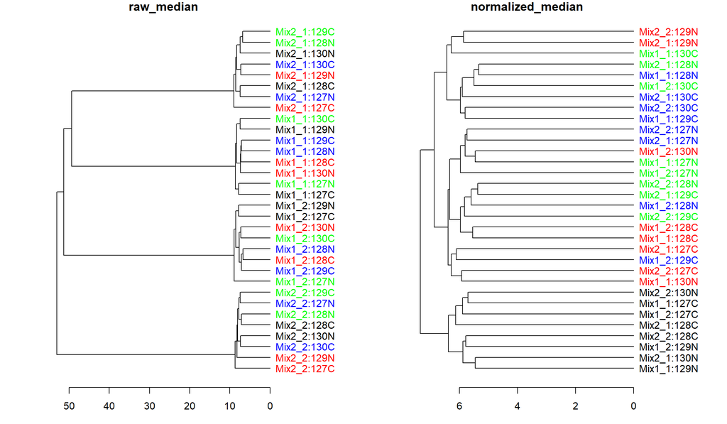

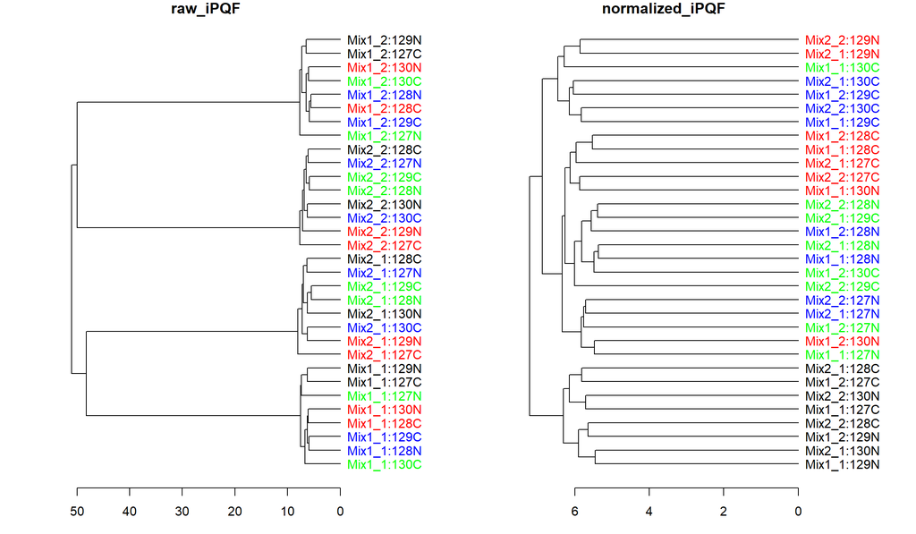

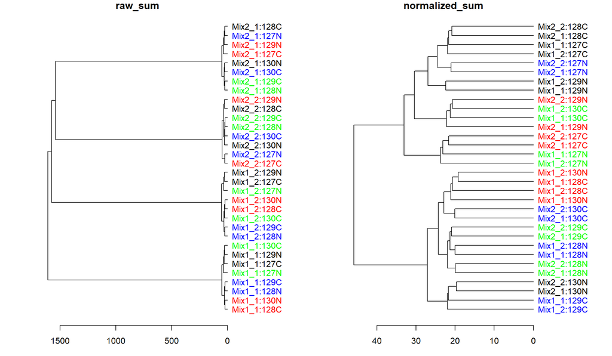

```r
par(mfrow=c(1,2))
for (i in 1:n.comp.variants){
  dendrogram_ils(dat.nonnorm.summ.w2[[variant.names[i]]] %>% select(-Protein), info=sample.info, paste('raw', variant.names[i], sep='_'))
  dendrogram_ils(dat.norm.summ.w2[[variant.names[i]]] %>% select(-Protein), info=sample.info, paste('normalized', variant.names[i], sep='_'))}
```

## 5.5 Run effect p-value plot

Below the histograms of p-values from the linear model explaining the response variable with Run as a covariate.

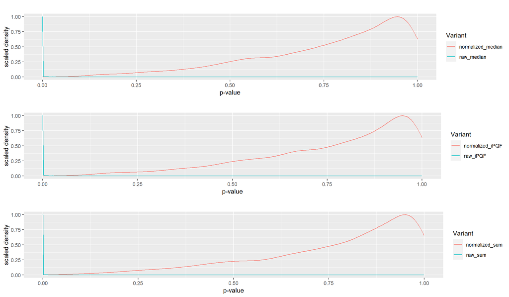

```r
plots <- vector('list', n.comp.variants)
for (i in 1:n.comp.variants){
dat <- list(dat.nonnorm.summ.l[[variant.names[i]]], dat.norm.summ.l[[variant.names[i]]])
names(dat) <- c(paste('raw', variant.names[i], sep='_'), paste('normalized', variant.names[i], sep='_'))
plots[[i]] <- run_effect_plot(dat)}
grid.arrange(grobs = plots, nrow=n.comp.variants)
```

# 6 DEA component: Moderated t-test

We look at the log2 fold changes of all conditions w.r.t. the reference condition with dilution ratio 0.5. Since we are working with a log2 unit scale already, this means that for each protein we just look at the difference in mean observation across all channels between one condition and the reference condition. Note that this is not the same as looking at the log2 of the ratio of mean raw intensities for each condition, nor the mean ratio of raw intensities for each condition, since $log_2 (\frac{mean(B)}{mean(A)}) \neq \frac{mean(log_2 (B))}{mean(log_2 (A))} \neq mean(\frac{log_2 (B)}{log_2 (A)})$.

To check whether these fold changes are significant (criterium: $q<0.05$), we use a [moderated t-test](http://www.biostat.jhsph.edu/~kkammers/software/eupa/R_guide.html) slightly adapted from the `limma` package, which in use cases like ours should improve statistical power over a regular t-test. In a nutshell, this is a t-test done independently for each protein, although the variance used in the calculation of the t-statistic is [moderated using some empirical Bayes estimation](https://doi.org/10.2202/1544-6115.1027). After testing, we make a correction for multiple testing using the Benjamini-Hochberg method in order to keep the FDR under control.

NOTE: - actually, lmFit (used in moderated_ttest) was built for log2-transformed data. However, supplying untransformed intensities can also work. This just means that the effects in the linear model are also additive on the untransformed scale, whereas for log-transformed data they are multiplicative on the untransformed scale. Also, there may be a bias which occurs from biased estimates of the population means in the t-tests, as mean(X) is not equal to exp(mean(log(X))).

```r
# design matrix as used in ANOVA testing.
design.matrix <- get_design_matrix(referenceCondition, sample.info)
dat.dea <- emptyList(names(dat.norm.summ.w2))
for (i in 1:n.comp.variants){
  # provide scale so moderated_ttest knows whether you input log2 or raw intensities.
  this_scale <- scale.vec
  d <- column_to_rownames(as.data.frame(dat.norm.summ.w2[[variant.names[i]]]), 'Protein')
  dat.dea[[variant.names[i]]] <- moderated_ttest(dat=d, design.matrix, scale=this_scale)}
```

For each condition, we now get the fold changes, moderated and unmoderated p-values, moderated and unmoderated q-values (BH-adjusted p-values), and some other details.

```r
colnames(dat.dea[[1]])
```

```
##  [1] "logFC_0.125" "logFC_0.667" "logFC_1"     "t.ord_0.125" "t.ord_0.667" "t.ord_1"
##  [7] "t.mod_0.125" "t.mod_0.667" "t.mod_1"     "p.ord_0.125" "p.ord_0.667" "p.ord_1"
## [13] "p.mod_0.125" "p.mod_0.667" "p.mod_1"     "q.ord_0.125" "q.ord_0.667" "q.ord_1"
## [19] "q.mod_0.125" "q.mod_0.667" "q.mod_1"     "df.r"        "df.0"        "s2.0"
## [25] "s2"          "s2.post"
```

# 7 Results comparison

Let’s look at how our component variants have affected the outcome of the DEA.

## 7.1 Confusion matrix

```r
cm <- conf_mat(dat.dea, 'q.mod', 0.05, spiked.proteins)
print_conf_mat(cm, referenceCondition)
```

|  | 0.125 vs 0.5 contrast median background | 0.125 vs 0.5 contrast median spiked | 0.125 vs 0.5 contrast iPQF background | 0.125 vs 0.5 contrast iPQF spiked | 0.125 vs 0.5 contrast sum background | 0.125 vs 0.5 contrast sum spiked |
| --- | --- | --- | --- | --- | --- | --- |
| not_DE | 4061 | 4 | 4059 | 5 | 4063 | 8 |
| DE | 3 | 15 | 5 | 14 | 1 | 11 |

|  | 0.125 vs 0.5 contrast median | 0.125 vs 0.5 contrast iPQF | 0.125 vs 0.5 contrast sum |
| --- | --- | --- | --- |
| Accuracy | 0.998 | 0.998 | 0.998 |
| Sensitivity | 0.789 | 0.737 | 0.579 |
| Specificity | 0.999 | 0.999 | 1.000 |
| PPV | 0.833 | 0.737 | 0.917 |
| NPV | 0.999 | 0.999 | 0.998 |

|  | 0.667 vs 0.5 contrast median background | 0.667 vs 0.5 contrast median spiked | 0.667 vs 0.5 contrast iPQF background | 0.667 vs 0.5 contrast iPQF spiked | 0.667 vs 0.5 contrast sum background | 0.667 vs 0.5 contrast sum spiked |
| --- | --- | --- | --- | --- | --- | --- |
| not_DE | 4062 | 17 | 4063 | 17 | 4064 | 18 |
| DE | 2 | 2 | 1 | 2 | 0 | 1 |

|  | 0.667 vs 0.5 contrast median | 0.667 vs 0.5 contrast iPQF | 0.667 vs 0.5 contrast sum |
| --- | --- | --- | --- |
| Accuracy | 0.995 | 0.996 | 0.996 |
| Sensitivity | 0.105 | 0.105 | 0.053 |
| Specificity | 1.000 | 1.000 | 1.000 |
| PPV | 0.500 | 0.667 | 1.000 |
| NPV | 0.996 | 0.996 | 0.996 |

|  | 1 vs 0.5 contrast median background | 1 vs 0.5 contrast median spiked | 1 vs 0.5 contrast iPQF background | 1 vs 0.5 contrast iPQF spiked | 1 vs 0.5 contrast sum background | 1 vs 0.5 contrast sum spiked |
| --- | --- | --- | --- | --- | --- | --- |
| not_DE | 4060 | 5 | 4061 | 5 | 4063 | 9 |
| DE | 4 | 14 | 3 | 14 | 1 | 10 |

|  | 1 vs 0.5 contrast median | 1 vs 0.5 contrast iPQF | 1 vs 0.5 contrast sum |
| --- | --- | --- | --- |
| Accuracy | 0.998 | 0.998 | 0.998 |
| Sensitivity | 0.737 | 0.737 | 0.526 |
| Specificity | 0.999 | 0.999 | 1.000 |
| PPV | 0.778 | 0.824 | 0.909 |
| NPV | 0.999 | 0.999 | 0.998 |

## 7.2 Correlation scatter plots

To see whether the three Summarization methods produce similar results on the detailed level of individual proteins, we make scatter plots and check the correlation of their fold changes and p-values.

For all conditions, we see the iPQF consistently produces slightly higher p-values in the $[0, 0.5]$ interval than the Median summarization, with which it correlates $>0.82$ overall. Towards $q=1$ the correlation is worse, but that is not surprising as that is the domain of housekeeping proteins, which moreover are not of particular interest. The Sum summarization resulted in very, very little significant observations.

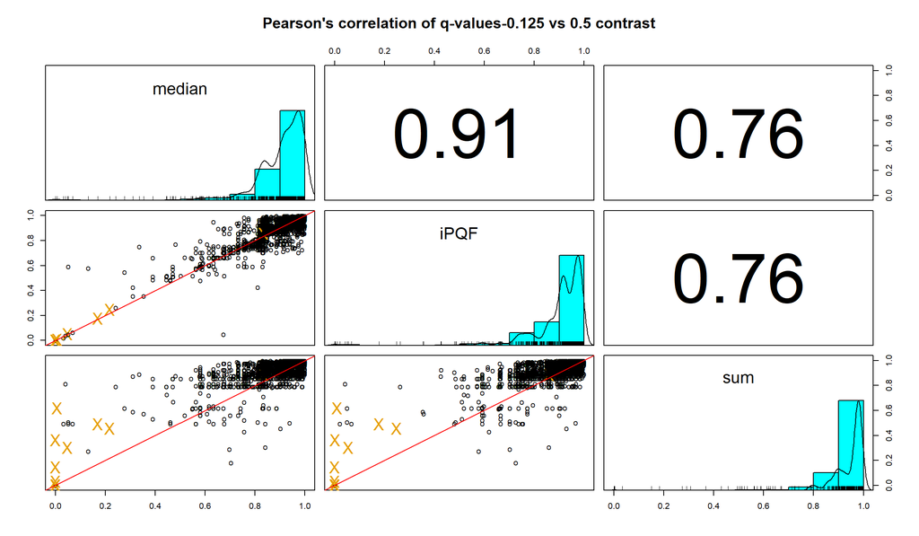

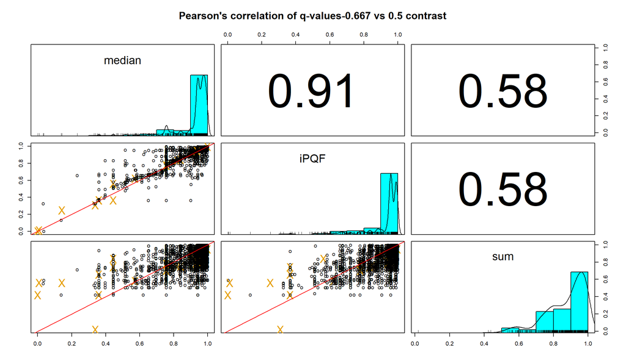

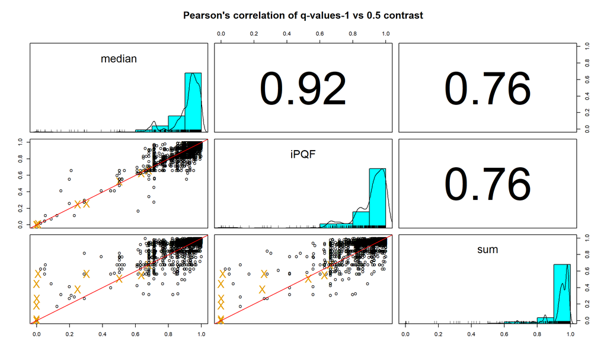

```r
scatterplot_ils(dat.dea, significance.cols, 'q-values', spiked.proteins)
```

The correlation metween Median summarization and iPQF is even higher for the fold changes: $>0.96$ for all conditions. This is to be expected based on the q-value plots, as a large difference in the test statistic can be due to a small difference in fold change. The plots involving Sum summarization have an anomaly around 0 fold change.

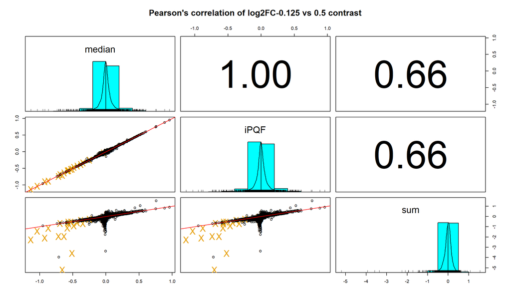

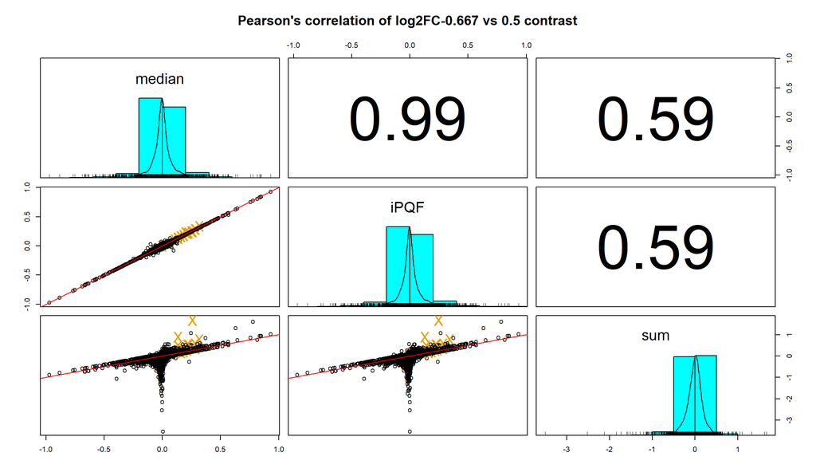

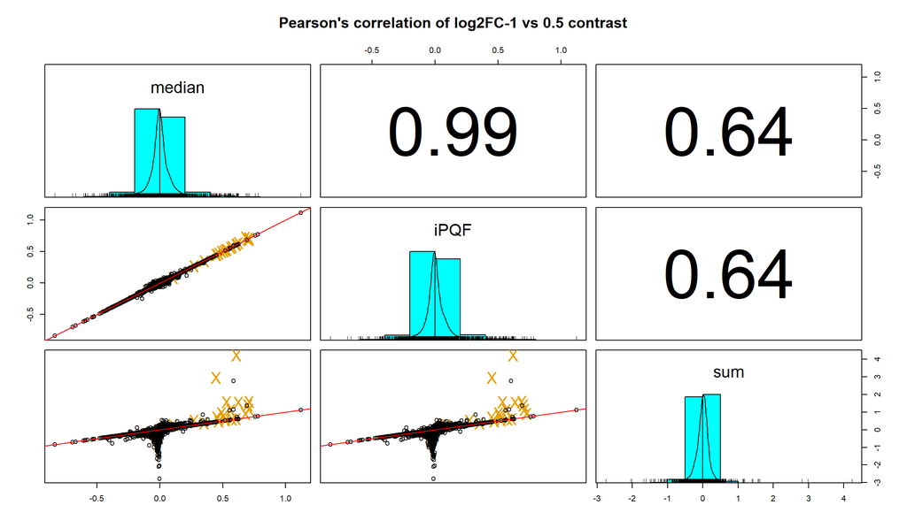

```r
scatterplot_ils(dat.dea, logFC.cols, 'log2FC', spiked.proteins)
```

## 7.3 Volcano plots

The volcano plot combines information on fold changes and statistical significance. The spike-in proteins are colored blue, and immediately it is clear that their fold changes dominate the region of statistical significance, which suggests the experiment and analysis were carried out successfully.

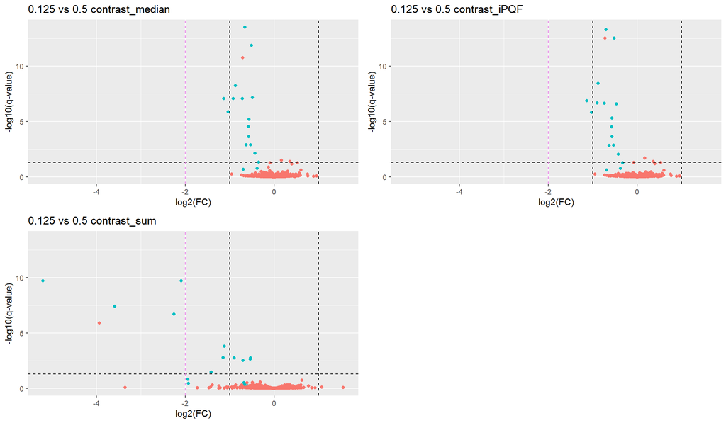

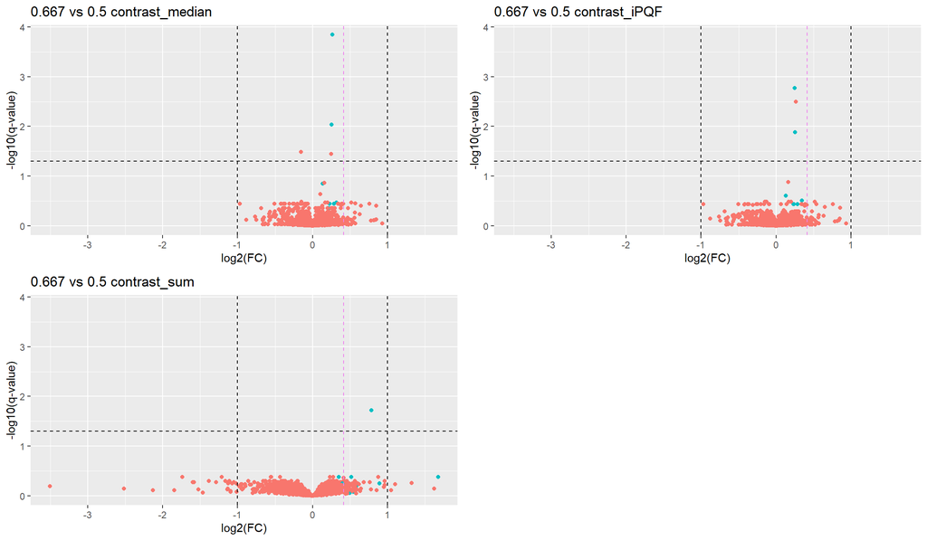

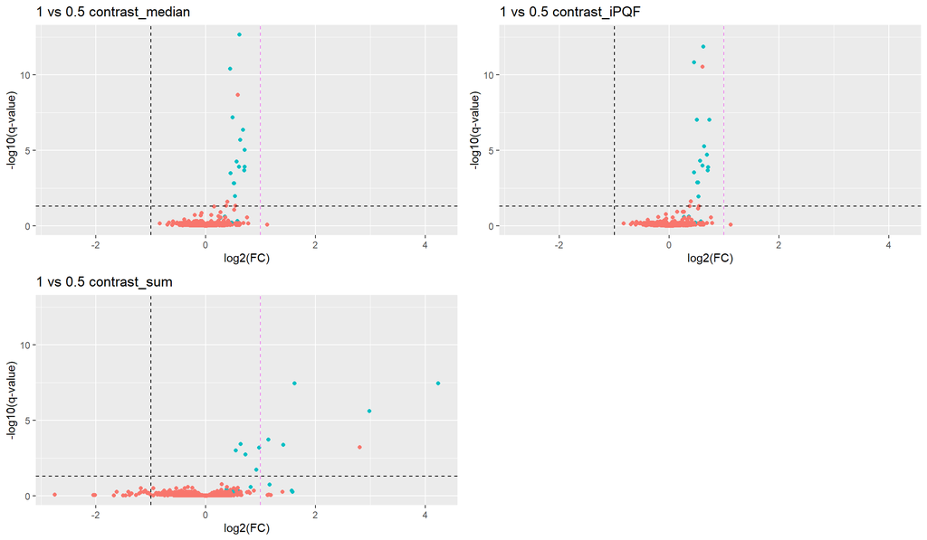

```r
for (i in 1:n.contrasts){
  volcanoplot_ils(dat.dea, i, spiked.proteins)}
```

## 7.4 Violin plots

On a ‘macroscopic’ scale, the best way to find out whether this experiment and subsequent analysis was successful is to check whether the spike-in proteins have attained the fold change that corresponds to their condition. Instead of plotting each protein individually, we make violin plots to get a sense of the general trend. The theoretical fold changes are indicated with red dotted lines.

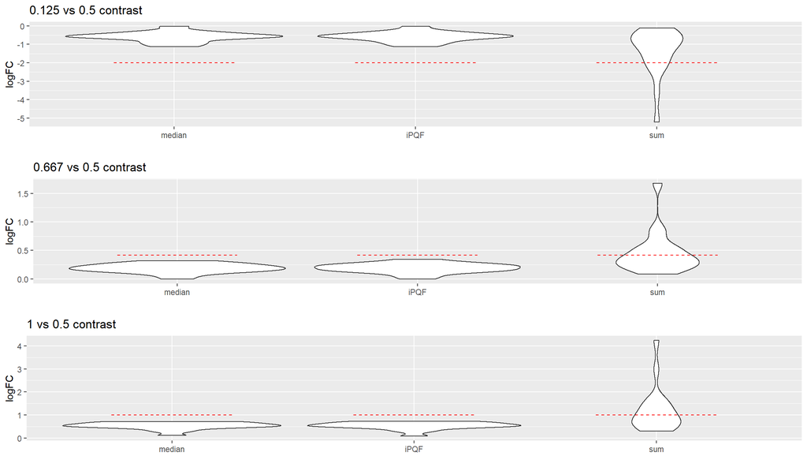

```r
# plot theoretical value (horizontal lines) and violin per variant
violinplot_ils(lapply(dat.dea, function(x) x[spiked.proteins, logFC.cols]), referenceCondition)
```

```r
save(dat.nonnorm.summ.l
     ,dat.norm.summ.l
     ,dat.nonnorm.summ.w
     ,dat.norm.summ.w
     ,dat.nonnorm.summ.w2
     ,dat.norm.summ.w2
     ,dat.dea, file='datadriven_summarization_outdata.rda')
```

# 8 Conclusions

For the given data set, the differences in proteomic outcomes between Median and iPQF normalization are quite small, both on the global and individual scale. Their differences with the Sum summarization outcomes are very large. The QC plots suggest that the Sum summarization obfuscates any work done by the normalization. This may be explained by the fact that sum summarization promotes not only *abundant* detections (at the PSM level) of proteins, but also *repeated* detections. Since repetition of detections in MS experiments is far from robust across runs, this is expected to introduce a great amount of stochasticity. Therefore, Sum summarization does not work when you have data from multiple runs. In such a case, it would be advised to use mean normalization instead.